# Mean Vector and Covariance Matrix Estimation under Heavy Tails

Daniel P. Palomar, Rui Zhou, and Xiwen Wang The Hong Kong University of Science and Technology (HKUST)

2023-04-29

> This vignette illustrates the usage of the package [`fitHeavyTail`](https://CRAN.R-project.org/package=fitHeavyTail) to estimate the mean vector and covariance matrix of heavy-tailed multivariate distributions such as the angular Gaussian, Cauchy, or Student’s $t$ distribution. The results are compared against existing benchmark functions from different packages.

# Installation

The package can be installed from [CRAN](https://CRAN.R-project.org/package=fitHeavyTail) or [GitHub](https://github.com/convexfi/fitHeavyTail):

```r
# install stable version from CRAN
install.packages("fitHeavyTail")

# install development version from GitHub
devtools::install_github("convexfi/fitHeavyTail")
```

To get help:

```r
library(fitHeavyTail)
help(package = "fitHeavyTail")
?fit_mvt
```

To cite [`fitHeavyTail`](https://CRAN.R-project.org/package=fitHeavyTail) in publications:

```r
citation("fitHeavyTail")
```

# Quick Start

To illustrate the simple usage of the package [`fitHeavyTail`](https://CRAN.R-project.org/package=fitHeavyTail), let’s start by generating some multivariate data under a Student’s $t$ distribution with significant heavy tails (degrees of freedom $\nu=4$):

```r
library(mvtnorm)  # package for multivariate t distribution
N <- 10   # number of variables
T <- 80   # number of observations
nu <- 4   # degrees of freedom for heavy tails

set.seed(42)
mu <- rep(0, N)
U <- t(rmvnorm(n = round(0.3*N), sigma = 0.1*diag(N)))
Sigma_cov <- U %*% t(U) + diag(N)  # covariance matrix with factor model structure
Sigma_scatter <- (nu-2)/nu * Sigma_cov
X <- rmvt(n = T, delta = mu, sigma = Sigma_scatter, df = nu)  # generate data
```

We can first estimate the mean vector and covariance matrix via the traditional sample estimates (i.e., sample mean and sample covariance matrix):

```r
mu_sm     <- colMeans(X)
Sigma_scm <- cov(X)
```

Then we can compute the robust estimates via the package [`fitHeavyTail`](https://CRAN.R-project.org/package=fitHeavyTail):

```r
library(fitHeavyTail)
fitted <- fit_mvt(X)
```

We can now compute the estimation errors and see the significant improvement:

```r
sum((mu_sm     - mu)^2)
```

```
#> [1] 0.2857323
```

```r
sum((fitted$mu - mu)^2)
```

```
#> [1] 0.1487845
```

```r
sum((Sigma_scm  - Sigma_cov)^2)
```

```
#> [1] 5.861138
```

```r
sum((fitted$cov - Sigma_cov)^2)
```

```
#> [1] 3.031499
```

To get a visual idea of the robustness, we can plot the shapes of the covariance matrices (true and estimated ones) on two dimensions. Observe how the heavy-tailed estimation follows the true one more closely than the sample covariance matrix:

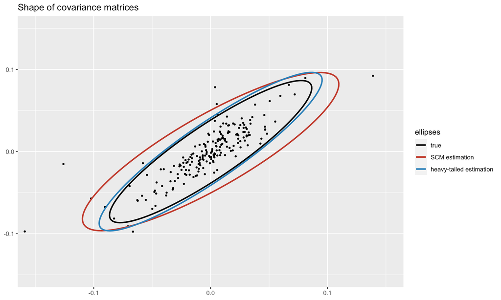

# Numerical Comparison with Existing Packages

In the following, we generate multivariate heavy-tailed Student’s $t$ distributed data and compare the performance of many different existing packages via 100 Monte Carlo simulations in terms of estimation accurary, measured by the mean squared error (MSE) and CPU time.

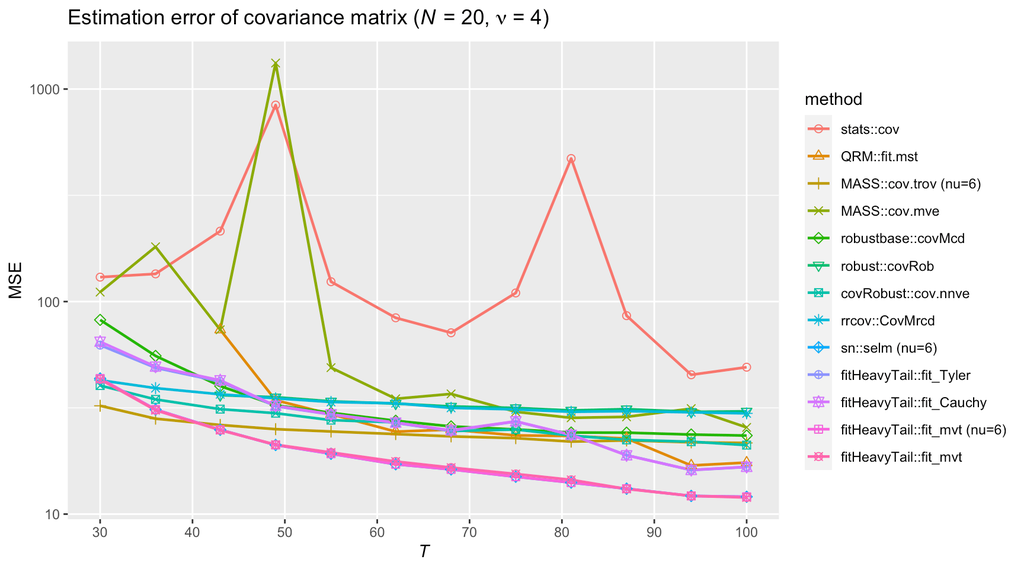

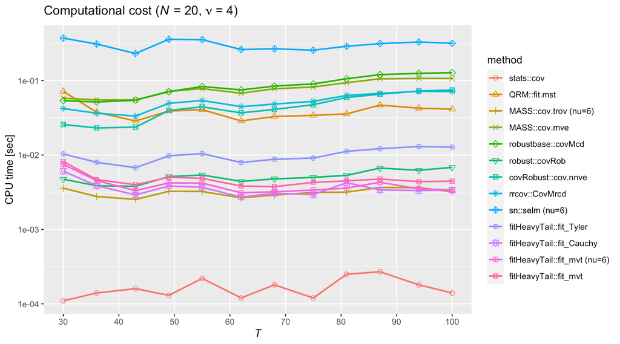

The following plot gives a nice overall perspective of the MSE vs. CPU time tradeoff of the different methods (note the ellipse at the bottom left that embraces the best four methods: `fitHeavyTail::fit_Tyler()`, `fitHeavyTail::fit_Cauchy()`, `fitHeavyTail::fit_mvt()`, and `fitHeavyTail::fit_mvt()` with fixed `nu = 6`):

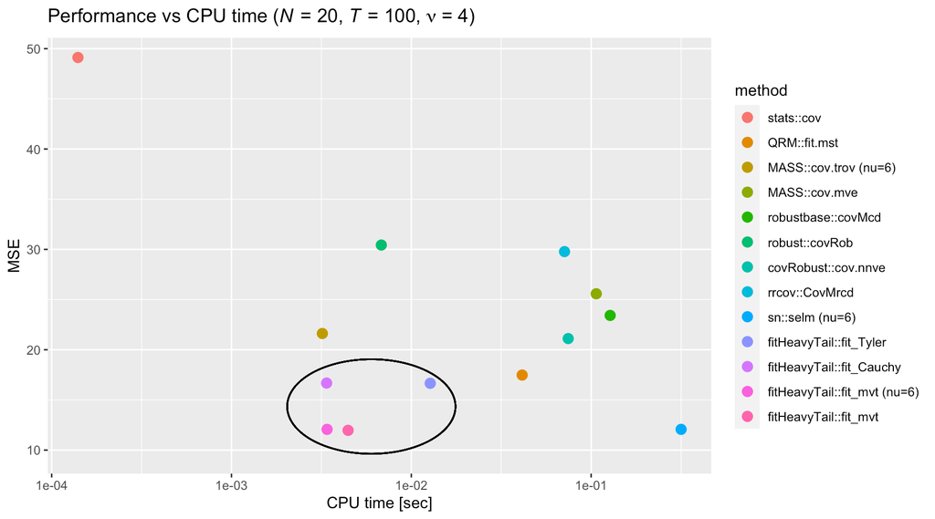

Concluding, the top choices seem to be (in order):

1. `fitHeavyTail::fit_mvt()` (either without fixing `nu` or with `nu = 6`),
2. `fitHeavyTail::fit_Cauchy()`,
3. `fitHeavyTail::fit_Tyler()`, and
4. `MASS::cov.trob()` (with the advantage of being preinstalled with base R, but with a worse estimation error).

The overall winner is `fitHeavyTail::fit_mvt()` by a big margin.

# Extension to Skewed Distributions

The empirical distribution of daily returns of some financial variables, such as exchange rates, equity prices, and interest rates, is often skewed. There are several different formulations of multivariate skewed $t$ distributions appearing in the literature (Lee and McLachlan, 2014) (Aas and Haff, 2006). The package now supports the multivariate generalized hyperbolic (GH) skewed $t$ distribution and provides a method to estimate the parameters of such distribution. It is implemented in the function `fitHeavyTail::fit_mvst()`. Below is a simple example to illustrate its usage:

```r
# parameter setting for GH Skewed t distribution
N <- 5
T <- 200
nu <- 6
mu <- rnorm(N)
scatter <- diag(N)
gamma <- rnorm(N)

# generate GH Skew t data via hierarchical structure
taus <- rgamma(n = T, shape = nu/2, rate = nu/2)
X <- matrix(data = mu, nrow = T, ncol = N, byrow = TRUE) +
     matrix(data = gamma, nrow = T, ncol = N, byrow = TRUE) / taus +
     mvtnorm::rmvnorm(n = T, mean = rep(0, N), sigma = scatter) / sqrt(taus)

# fit GH Skew t model
fitted <- fit_mvst(X)
```

# Algorithms

In essence, all the algorithms are based on the maximum likelihood estimation (MLE) of some assumed distribution given the observed data. The difficulty comes from the fact that the optimal solution to such MLE formulations becomes too involved in the form of a fixed-point equation and the framework of Majorization-Minimization (MM) algorithms (Sun et al., 2017) becomes key to derive efficient algorithms.

In some cases, the probability distribution function becomes too complicated to manage directly (like the multivariate Student’s $t$ distribution) and it is necessary to resort to a hierarchical distribution that involves some latent variables. In order to deal with such hidden variables, one has to resort to the Expectation-Maximization (EM) algorithm, which interestingly is an instance of the MM algorithm.

- The function `fitHeavyTail::fit_Tyler()` normalizes the centered samples $\bar{\boldsymbol{x}}_t = \boldsymbol{x}_t - \boldsymbol{\mu}$ (where $\boldsymbol{\mu}$ has been previously estimated), which then have an angular Gaussian distribution on the sphere, and performs an MLE based on the MM algorithm (Sun et al., 2014). The formulation including a regularization term is
  $$\begin{array}{ll}
  \underset{\boldsymbol{\Sigma}}{\textsf{minimize}} &
  \begin{aligned}[t]
  \frac{T}{2}\log\det(\boldsymbol{\Sigma}) +
  \frac{N}{2}\sum\limits_{t=1}^{T}\log{\left(\bar{\boldsymbol{x}}_t^{\mkern-1mu\raise-1mu\textsf{T}}\boldsymbol{\Sigma}^{-1}\bar{\boldsymbol{x}}_t\right)}\hspace{2cm}\\
  \color{darkred}{+ \;\alpha
  \left(N\log\left(\textsf{Tr}\left(\boldsymbol{\Sigma}^{-1}\boldsymbol{T}\right)\right)
  + \log\det(\boldsymbol{\Sigma})\right)}
  \end{aligned}
  \end{array}$$
  where $\boldsymbol{T}$ is the target matrix (e.g., $\boldsymbol{T} = \boldsymbol{I}$ or $\boldsymbol{T} = \frac{1}{N}\textsf{Tr}(\boldsymbol{S})\times\boldsymbol{I}$, with $\boldsymbol{S}$ being the sample covariance matrix). This leads to the iteration step
  $$\boldsymbol{\Sigma}_{k+1} =
  (1 -
  \rho)\frac{N}{T}\sum\limits_{t=1}^{T}\frac{\bar{\boldsymbol{x}}_t\bar{\boldsymbol{x}}_t^{\mkern-1mu\raise-1mu\textsf{T}}}{\bar{\boldsymbol{x}}_t^{\mkern-1mu\raise-1mu\textsf{T}}\boldsymbol{\Sigma}_k^{-1}\bar{\boldsymbol{x}}_t}
  +
  \rho\frac{N}{\textsf{Tr}\left(\boldsymbol{\Sigma}_k^{-1}\boldsymbol{T}\right)}\boldsymbol{T},$$
  where $\rho = \frac{\alpha}{T/2 + \alpha}$ or $\alpha = \frac{T}{2}\frac{\rho}{1 - \rho}$, and initial point $\boldsymbol{\Sigma}_{0} = \boldsymbol{S}$. For better numerical stability, one can further normalize the estimate at each iteration: $\boldsymbol{\Sigma}_{k+1} \leftarrow \boldsymbol{\Sigma}_{k+1}/\textsf{Tr}\left(\boldsymbol{\Sigma}_{k+1}\right)$. The iterations converge to the solution up to a scaling factor if and only if $1 + \frac{2}{T}\alpha > \frac{N}{T}$ or, equivalently, $\rho > 1 - \frac{T}{N}$ (Sun et al., 2014) (the correct scaling factor is later obtained via a robust fitting method). If instead the regularization term $\color{darkred}{\textsf{Tr}\left(\boldsymbol{\Sigma}^{-1}\boldsymbol{T}\right) + \log\det(\boldsymbol{\Sigma})}$ is used, the iteration step becomes
  $$\boldsymbol{\Sigma}_{k+1} =
  (1 -
  \rho)\frac{N}{T}\sum\limits_{t=1}^{T}\frac{\bar{\boldsymbol{x}}_t\bar{\boldsymbol{x}}_t^{\mkern-1mu\raise-1mu\textsf{T}}}{\bar{\boldsymbol{x}}_t^{\mkern-1mu\raise-1mu\textsf{T}}\boldsymbol{\Sigma}_k^{-1}\bar{\boldsymbol{x}}_t}
  + \rho\boldsymbol{T}.$$
- The function `fitHeavyTail::fit_Cauchy()` assumes that the data follows a multivariate Cauchy distribution ($t$ distribution with $\nu=1$) and performs an MLE based on the MM algorithm (Sun et al., 2015). The formulation including a regularization term is
  $$\begin{array}{ll}
  \underset{\boldsymbol{\mu},\boldsymbol{\Sigma}}{\textsf{minimize}} &
  \begin{aligned}[t]
  & \frac{T}{2}\log\det(\boldsymbol{\Sigma}) +
  \frac{N+1}{2}\sum\limits_{t=1}^{T}\log{\left(1+(\boldsymbol{x}_t -
  \boldsymbol{\mu})^{\mkern-1mu\raise-1mu\textsf{T}}\boldsymbol{\Sigma}^{-1}(\boldsymbol{x}_t
  - \boldsymbol{\mu})\right)}\\
  & \color{darkred}{+\;\alpha
  \left(N\log\left(\textsf{Tr}\left(\boldsymbol{\Sigma}^{-1}\boldsymbol{T}\right)\right)
  + \log\det(\boldsymbol{\Sigma})\right) + \gamma \log{\left(1 +
  (\boldsymbol{\mu} -
  \boldsymbol{t})^{\mkern-1mu\raise-1mu\textsf{T}}\boldsymbol{\Sigma}^{-1}(\boldsymbol{\mu}
  - \boldsymbol{t})\right)}}
  \end{aligned}
  \end{array}$$
  where $\boldsymbol{t}$ and $\boldsymbol{T}$ are the targets for $\boldsymbol{\mu}$ and $\boldsymbol{\Sigma}$, respectively. This leads to the following (accelerated) iteration step (Algorithm 4 in (Sun et al., 2015)):
  $$\boldsymbol{\mu}_{k+1} = \frac{(N+1)\sum_{t=1}^{T}
  w_t\left(\boldsymbol{\mu}_k,\boldsymbol{\Sigma}_k\right)\boldsymbol{x}_t
  + 2\gamma
  w_{\textsf{tgt}}\left(\boldsymbol{\mu}_k,\boldsymbol{\Sigma}_k\right)\boldsymbol{t}}{(N+1)\sum_{t=1}^{T}
  w_t\left(\boldsymbol{\mu}_k,\boldsymbol{\Sigma}_k\right) + 2\gamma
  w_{\textsf{tgt}}\left(\boldsymbol{\mu}_k,\boldsymbol{\Sigma}_k\right)}$$
  and
  $$\boldsymbol{\Sigma}_{k+1} = \beta_k
  \left\{
  (1 -
  \rho)\frac{N+1}{T}\sum\limits_{t=1}^{T}w_t\left(\boldsymbol{\mu}_k,\boldsymbol{\Sigma}_k\right)\left(\boldsymbol{x}_t
  - \boldsymbol{\mu}_{k+1}\right)\left(\boldsymbol{x}_t -
  \boldsymbol{\mu}_{k+1}\right)^{\mkern-1mu\raise-1mu\textsf{T}}\\\hspace{6cm}
  +
  \rho\left(\frac{N}{\textsf{Tr}\left(\boldsymbol{\Sigma}_k^{-1}\boldsymbol{T}\right)}\boldsymbol{T}
  +
  \frac{\gamma}{\alpha}w_\textsf{tgt}\left(\boldsymbol{\mu}_k,\boldsymbol{\Sigma}_k\right)\left(\boldsymbol{t}
  - \boldsymbol{\mu}_{k+1}\right)\left(\boldsymbol{t} -
  \boldsymbol{\mu}_{k+1}\right)^{\mkern-1mu\raise-1mu\textsf{T}}\right)
  \right\}$$
  where $\rho = \frac{\alpha}{T/2 + \alpha}$,
  $$\begin{aligned}
  w_t\left(\boldsymbol{\mu},\boldsymbol{\Sigma}\right) &= \frac{1}{1 +
  \left(\boldsymbol{x}_t -
  \boldsymbol{\mu}\right)^{\mkern-1mu\raise-1mu\textsf{T}}\boldsymbol{\Sigma}^{-1}\left(\boldsymbol{x}_t
  - \boldsymbol{\mu}\right)},\\
  w_\textsf{tgt}\left(\boldsymbol{\mu},\boldsymbol{\Sigma}\right) &=
  \frac{1}{1 + \left(\boldsymbol{t} -
  \boldsymbol{\mu}\right)^{\mkern-1mu\raise-1mu\textsf{T}}\boldsymbol{\Sigma}^{-1}\left(\boldsymbol{t}
  - \boldsymbol{\mu}\right)},\\
  \beta_k &=
  \frac{T+2\gamma}{(N+1)\sum_{t=1}^{T}w_t\left(\boldsymbol{\mu}_k,\boldsymbol{\Sigma}_k\right)
  + 2\gamma
  w_\textsf{tgt}\left(\boldsymbol{\mu}_k,\boldsymbol{\Sigma}_k\right)},
  \end{aligned}$$
  and initial point $\boldsymbol{\mu}_{0} = \frac{1}{T}\sum_{t=1}^{T}\boldsymbol{x}_t$ and $\boldsymbol{\Sigma}_{0} = \boldsymbol{S}$ (note that this initial point is not totally correct due to a scaling factor). The iterations converge to the solution if and only if the conditions of Corollary 3 in (Sun et al., 2015) are satisfied.
- The function `fitHeavyTail::fit_mvt()` assumes the data follows a multivariate Student’s $t$ distribution and performs an MLE based on the EM algorithm (Liu and Rubin, 1995; Liu et al., 1998). The MLE formulation (without missing values) is
  $$\begin{array}{ll}
  \underset{\boldsymbol{\mu},\boldsymbol{\Sigma},\nu}{\textsf{minimize}}
  &
  \begin{aligned}[t]
  \frac{T}{2}\log\det(\boldsymbol{\Sigma}) +
  \frac{N+\nu}{2}\sum\limits_{t=1}^{T}\log{\left(1+\frac{1}{\nu}(\boldsymbol{x}_t
  -
  \boldsymbol{\mu})^{\mkern-1mu\raise-1mu\textsf{T}}\boldsymbol{\Sigma}^{-1}(\boldsymbol{x}_t
  - \boldsymbol{\mu})\right)}\\
  -\; T\log{\Gamma\left(\frac{N+\nu}{2}\right)}
  + T\log{\Gamma\left(\frac{\nu}{2}\right)}
  + \frac{TN}{2}\log{\nu}.
  \end{aligned}
  \end{array}$$
  Since its direct minimization is complicated, the EM algorithm instead iteratively optimizes the Q function at iteration $k$:
  $$\begin{array}{ll}
  \underset{\boldsymbol{\mu},\boldsymbol{\Sigma},\nu}{\textsf{minimize}}
  &
  \begin{aligned}[t]
  \frac{T}{2}\log\det(\boldsymbol{\Sigma}) +
  \sum\limits_{t=1}^{T}\left\{\frac{\textsf{E}_k[\tau_t]}{2}(\boldsymbol{x}_t
  -
  \boldsymbol{\mu})^{\mkern-1mu\raise-1mu\textsf{T}}\boldsymbol{\Sigma}^{-1}(\boldsymbol{x}_t
  - \boldsymbol{\mu}) + \frac{\nu}{2}\textsf{E}_k[\tau_t] -
  \frac{\nu}{2}\textsf{E}_k[\log{\tau_t]}\right\}\\
  -\; \frac{T\nu}{2}\log{\frac{\nu}{2}} +
  T\log{\Gamma\left(\frac{\nu}{2}\right)}
  \end{aligned}
  \end{array}$$
  where
  $$\textsf{E}_k[\tau_t] = \frac{\nu_k + N}{\nu_k + \left(\boldsymbol{x}_t -
  \boldsymbol{\mu}_k\right)^{\mkern-1mu\raise-1mu\textsf{T}}\boldsymbol{\Sigma}_k^{-1}\left(\boldsymbol{x}_t
  - \boldsymbol{\mu}_k\right)}.$$
  The (accelerated) solution is given by
  $$\boldsymbol{\mu}_{k+1} =
  \frac{\sum_{t=1}^{\mkern-1mu\raise-1mu\textsf{T}}\textsf{E}_k[\tau_t]\boldsymbol{x}_t}{\sum_{t=1}^{\mkern-1mu\raise-1mu\textsf{T}}\textsf{E}_k[\tau_t]},$$
  $$\boldsymbol{\Sigma}_{k+1} =
  \frac{1}{\alpha_k}\frac{1}{T}\sum_{t=1}^{T}\textsf{E}_k[\tau_t]\left(\boldsymbol{x}_t
  - \boldsymbol{\mu}_{k+1}\right)\left(\boldsymbol{x}_t -
  \boldsymbol{\mu}_{k+1}\right)^{\mkern-1mu\raise-1mu\textsf{T}},$$
  with $\alpha_k = \frac{1}{T}\sum_{t=1}^{\mkern-1mu\raise-1mu\textsf{T}}\textsf{E}_k[\tau_t]$, and $\nu_{k+1}$ can be found by:
  - method ECM based on the Q function:

  $$\nu_{k+1} = \arg\min_\nu
  \left\{\frac{\nu}{2}\sum_{t=1}^{T}\left(\textsf{E}_k[\tau_t] -
  \textsf{E}_k[\log{\tau_t]}\right) - \frac{\nu}{2}T\log{\frac{\nu}{2}} +
  T\log{\Gamma\left(\frac{\nu}{2}\right)}\right\};$$
  - method ECME based directly on the likelihood:

  $$\nu_{k+1} = \arg\min_\nu \left\{
  \frac{N + \nu}{2}\sum_{t=1}^{T}\log{\left(\nu + \left(\boldsymbol{x}_t -
  \boldsymbol{\mu}_{k+1}\right)\boldsymbol{\Sigma}_{k+1}^{-1}\left(\boldsymbol{x}_t
  -
  \boldsymbol{\mu}_{k+1}\right)^{\mkern-1mu\raise-1mu\textsf{T}}\right)}\\\hspace{6cm}
  - T\log{\Gamma\left(\frac{N + \nu}{2}\right)} +
  T\log{\Gamma\left(\frac{\nu}{2}\right)} - \frac{\nu}{2}T\log{\nu}
  \right\};$$
  - more stable methods OPP (Ollila et al., 2021) and POP (Pascal et al., 2021) based on random matrix theory.

  The initial point is $\boldsymbol{\mu}_{0} = \frac{1}{T}\sum_{t=1}^{T}\boldsymbol{x}_t$, $\boldsymbol{\Sigma}_{0} = \frac{\nu_0-2}{\nu_0}\boldsymbol{S}$, and $\nu_0 = 2/\kappa + 4$, with $\kappa = \left[\frac{1}{3}\frac{1}{N}\sum_{i=1}^N \textsf{kurt}_i\right]^+$ and
  $$\textsf{kurt}_i
  = \frac{(T-1)}{(T-2)(T-3)}\left((T+1)\left(\frac{m_i^{(4)}}{\big(m_i^{(2)}\big)^2}
  - 3\right) + 6\right),$$
  where $m_i^{(q)}=\frac{1}{T}\sum_{t=1}^{\mkern-1mu\raise-1mu\textsf{T}}(x_{it}-\bar{x}_i)^q$ denotes the $q$th order sample moment. The algorithm with missing values in $\boldsymbol{x}_t$ becomes more cumbersome but it is essentially the same idea. This function can also incorporate a factor model structure on the covariance matrix $\boldsymbol{\Sigma} = \boldsymbol{B}\boldsymbol{B}^{\mkern-1mu\raise-1mu\textsf{T}}+ {\sf Diag}(\boldsymbol{\psi})$, which requires a more sophisticated algorithm (Zhou et al., 2019).
- The function `fitHeavyTail::fit_mvst()` assumes the data follows a multivariate skew $t$ distribution and performs an MLE based on the EM algorithm (Aas and Haff, 2006). Suppose $\boldsymbol{x}_{t}$ is a random vector following the GH Skew t distribution, its probability density function (pdf) is decided by four parameters, namely, location vector $\boldsymbol{\mu}$, scatter matrix $\boldsymbol{\Sigma}$, degrees of freedom $\nu$, and skewness vector $\boldsymbol{\gamma}$. When $\boldsymbol{\gamma} = \boldsymbol{0}$, the GH skew $t$ reduces to the Student’s $t$ distribution (considered in `fitHeavyTail::fit_mvt()`). The expression of the GH skew $t$ pdf is rather complicated:
  $$f\left(\boldsymbol{x}\right)=\frac{2^{1-\frac{\nu+N}{2}}}{\Gamma\left(\frac{\nu}{2}\right)\left(\pi\nu\right)^{\frac{N}{2}}\vert\boldsymbol{\Sigma}\vert^{\frac{1}{2}}}\frac{K_{\frac{\nu+N}{2}}\left(\left[\left(\nu+d\left(\boldsymbol{x}\right)\right)\boldsymbol{\gamma}^{\mkern-1mu\raise-1mu\textsf{T}}\boldsymbol{\Sigma}^{-1}\boldsymbol{\gamma}\right]^{\frac{1}{2}}\right)\exp\left(\left(\boldsymbol{x}-\boldsymbol{\mu}\right)^{\mkern-1mu\raise-1mu\textsf{T}}\boldsymbol{\Sigma}^{-1}\boldsymbol{\gamma}\right)}{\left[\left(\nu+d\left(\boldsymbol{x}\right)\right)\boldsymbol{\gamma}^{T}\boldsymbol{\Sigma}^{-1}\boldsymbol{\gamma}\right]^{-\frac{\nu+N}{4}}\left(1+\frac{d\left(\boldsymbol{x}\right)}{\nu}\right)^{\frac{\nu+N}{2}}},$$
  where $K_{\alpha}$ is the modified Bessel function and $d\left(\boldsymbol{x}\right)=\left(\boldsymbol{x}-\boldsymbol{\mu}\right)^{\mkern-1mu\raise-1mu\textsf{T}}\boldsymbol{\Sigma}^{-1}\left(\boldsymbol{x}-\boldsymbol{\mu}\right)$. Fortunately, $\boldsymbol{x}_{t}$ can be represented in a hierarchical structure:
  $$\begin{aligned}
  \boldsymbol{x}_{t}\lvert\tau &
  \sim\mathcal{N}\left(\boldsymbol{\mu}+\frac{1}{\tau_{t}}\boldsymbol{\gamma},\frac{1}{\tau_{t}}\boldsymbol{\Sigma}\right),\\
  \tau_{t} & \sim\text{Gamma}\left(\frac{\nu}{2},\frac{\nu}{2}\right).
  \end{aligned}$$
  Making use of such structure, an EM based algorithm has been proposed in (Aas and Haff, 2006) to obtain the MLE estimators of these parameters.

# References

Aas, K., and Haff, I. H. (2006). The generalized hyperbolic skew student’st-distribution. *Journal of Financial Econometrics*, *4*(2), 275–309.

Lee, S., and McLachlan, G. J. (2014). Finite mixtures of multivariate skew t-distributions: Some recent and new results. *Statistics and Computing*, *24*(2), 181–202.

Liu, C., and Rubin, D. B. (1995). ML estimation of the t-distribution using EM and its extensions, ECM and ECME. *Statistica Sinica*, *5*(1), 19–39.

Liu, C., Rubin, D. B., and Ying Nian Wu, and. (1998). Parameter expansion to accelerate EM: The PX-EM algorithm. *Biometrika*, *85*(4), 755–770.

Ollila, E., Palomar, D. P., and Pascal, F. (2021). [Shrinking the eigenvalues of M-estimators of covariance matrix](https://doi.org/10.1109/TSP.2020.3043952). *IEEE Transactions on Signal Processing*, *69*, 256–269.

Pascal, F., Ollila, E., and Palomar, D. P. (2021). [Improved estimation of the degree of freedom parameter of multivariate t-distribution](https://doi.org/10.23919/EUSIPCO54536.2021.9616162).

Sun, Y., Babu, P., and Palomar, D. P. (2014). [Regularized Tyler’s scatter estimator: Existence, uniqueness, and algorithms](https://doi.org/10.1109/TSP.2014.2348944). *IEEE Trans. Signal Processing*, *62*(19), 5143–5156.

Sun, Y., Babu, P., and Palomar, D. P. (2015). [Regularized robust estimation of mean and covariance matrix under heavy-tailed distributions](https://doi.org/10.1109/TSP.2015.2417513). *IEEE Trans. Signal Processing*, *63*(12), 3096–3109.

Sun, Y., Babu, P., and Palomar, D. P. (2017). [Majorization-minimization algorithms in signal processing, communications, and machine learning](https://doi.org/10.1109/TSP.2016.2601299). *IEEE Transactions on Signal Processing*, *65*(3), 794–816.

Zhou, R., Liu, J., Kumar, S., and Palomar, D. P. (2019). [Robust factor analysis parameter estimation](https://arxiv.org/abs/1909.12530). *Lecture Notes in Computer Science (LNCS)*.